# The Illusion of a Monolithic Creole: The Role of Race in the Singlish Network Lexicon

Elise Lim

2026-04-17

# Setup and Libraries

All packages used in the analysis are loaded here.

# Data Import

```r
# Read raw data
responses <- read.csv('../data/cleaned_responses_long.csv', row.names = 1) |>
  mutate(cue = tolower(cue), # convert all responses to lower case letters
         R1 = str_to_lower(iconv(R1, to = "UTF-8", sub = "")),
         R2 = str_to_lower(iconv(R2, to = "UTF-8", sub = "")),
         R3 = str_to_lower(iconv(R3, to = "UTF-8", sub = ""))
  )

participants <- read.csv('../data/participant_information.csv')

merged <- left_join(responses, participants, by = 'ResponseId')

# add R2 and R3 as unique rows as well
merged_long <- merged |>
  pivot_longer(cols = c(R1, R2, R3), names_to = "response.round", values_to = "response") |>
  filter(!is.na(response) & response != "") |>
  filter(str_length(str_trim(response)) > 1) |>
  distinct(ResponseId, cue, response, .keep_all = TRUE)

cue_list <- read.csv("../data/wiki_300_cue_list.csv", row.names = 1)
```

# Data Pre-processing

## Participant Exclusion

### Birth and Residence in Singapore

```r
# Count of participants who resided and were born in Singapore
merged_long %>%
  distinct(ResponseId, Country.Residence, Country.Birth) %>%
  count(Country.Residence, Country.Birth)
```

```
## # A tibble: 13 × 3
##    Country.Residence        Country.Birth                n
##    <chr>                    <chr>                    <int>
##  1 Malaysia                 Singapore                    1
##  2 Singapore                Australia                    3
##  3 Singapore                Brunei Darussalam            1
##  4 Singapore                China                        9
##  5 Singapore                India                        9
##  6 Singapore                Indonesia                    5
##  7 Singapore                Malaysia                    40
##  8 Singapore                Myanmar                      2
##  9 Singapore                Philippines                  2
## 10 Singapore                Singapore                  531
## 11 Singapore                Tajikistan                   1
## 12 Singapore                United States of America     1
## 13 United States of America Singapore                    1
```

Since I am focusing on the network of Singlish lexicon, I will focus on Singaporeans who were born in and reside in Singapore. Hence, I will exclude participants whose birth country or country of residence is not Singapore.

```r
df <- merged_long %>%
  filter(
    `Country.Birth` %in% c("Singapore") &
    `Country.Residence` %in% c("Singapore")
  )
```

### Race

```r
# Count of participants from each race who was born and resided in Singapore
df %>% distinct(ResponseId, Race, Race_4_TEXT) %>% count(Race, Race_4_TEXT)
```

```
## # A tibble: 7 × 3
##   Race    Race_4_TEXT          n
##   <chr>   <chr>            <int>
## 1 Chinese ""                 505
## 2 Indian  ""                  12
## 3 Malay   ""                  10
## 4 Other   "Ceylonese"          1
## 5 Other   "Eurasian"           1
## 6 Other   "Filipino"           1
## 7 Other   "Indian-Chinese"     1
```

Since the races in ‘Other’ category have too small a sample size to draw meaningful conclusions, I will focus on the three larger races in Singapore: Chinese, Malay and Indians.

There are too many Chinese groups compared to the other races. For my research question, I will randomly sample Chinese participants results until the quality of yield is the same (ie. same number of associations as Malays and Indians). This allows for a similar percentage of each demographic represented. This downsampling will be conducted below.

```r
df <- df %>%
  filter(`Race` %in% c("Chinese", 'Malay', 'Indian')) %>%

  # move cue words and responses to front
  relocate(cue, response)
```

## Response Level Cleaning

Data was cleaned following a procedure similar to the one used by the original Small World of Words project (De Deyne et al., 2019).

```r
df2 <- df %>%

  # remove canonical forms, definite and indefinite articles ()
  mutate(
    response_clean = str_replace_all(response, "(?i)\\b(a|an|the|to)\\b", ""),
    response_clean = str_squish(response_clean)
  ) %>%

  # remove empty rows that become empty after cleaning
  filter(response_clean!= "" & !is.na(response_clean)) %>%

  # remove responses that is the same as cue word
  filter(cue != response_clean) %>%

  mutate(response = response_clean)

# to see the cue-response pairs that are removed
# df %>% anti_join(df2, by = c("ResponseId", "cue", "response.round")) %>%  select(cue, response)

num_rows_removed <- nrow(df) - nrow(df2)
print(paste("Total rows removed:", num_rows_removed))
```

```
## [1] "Total rows removed: 73"
```

```r
print(paste("Percentage of responses removed:", round(num_rows_removed / nrow(df) * 100,3), "%"))
```

```
## [1] "Percentage of responses removed: 0.256 %"
```

When participants were unsure about cue words, they should leave it blank. Yet, there were some participants who responded with “don’t know”, “not sure” or “no idea”. Some cue words have this meaning (eg. catch no ball), so I checked if multiple people gave the same target phrase to a specific cue. If so, the target phrase might be a legitimate colloquial association rather than just someone skipping the question.

```r
target_phrases <- c("don't know", "dont know", "not sure", "no idea")

df_with_counts <- df2 %>%
  group_by(cue, response) %>%
  mutate(response_freq = n()) %>%
  ungroup()

# kept only the rows where the response is a target phrase AND it only appeared once (n == 1)
excluded_phrases <- df_with_counts %>%
  filter(response %in% target_phrases & response_freq == 1) %>%
  select(-response_freq)

# Keep the rows that are NOT the excluded phrases
df3 <- df2 %>% anti_join(excluded_phrases, by = c("ResponseId", "cue", "response"))

print(paste("Rows excluded:", nrow(excluded_phrases)))
```

```
## [1] "Rows excluded: 62"
```

```r
print(paste("Percentage of rows excluded:", round(nrow(excluded_phrases) / nrow(df2) * 100, 3), "%"))
```

```
## [1] "Percentage of rows excluded: 0.218 %"
```

```r
print(paste("Rows remaining in df3:", nrow(df3)))
```

```
## [1] "Rows remaining in df3: 28350"
```

```r
# cue words that were kept because multiple people said these target phrases
kept_targets <- df3 %>%
  filter(tolower(response) %in% target_phrases) %>%
  select(cue, response) %>%
  distinct()

kable(kept_targets, caption = "Kept Target Phrases (since more than one person said them for the same cue")
```

Kept Target Phrases (since more than one person said them for the same cue

| cue | response |
| --- | --- |
| liek boh kiew | not sure |
| catch no ball | no idea |

### Investigating removal of N-grams

De Deyne et al. (2019) excluded participants where more than 30% of responses were multi-word responses (more than one word). This was to filter out participants who may have misunderstood the task and gave long definitions instead of single word associations.

To see how much data I would lose if I were to adopt this exclusion criteria, I will first calculate the percentage of responses that are multi-word responses (n > 1). Then, I will apply the exclusion criteria and calculate the exact percentage of data lost.

```r
total_responses <- nrow(df3)
initial_response_count <- total_responses

# count responses with more than one word
ngram_count <- df3 %>%
  filter(str_count(response, "\\w+") > 1) %>%
  nrow()

# calculate percentage
percentage_removed <- (ngram_count / total_responses) * 100

print(paste("Total responses in df3:", total_responses))
```

```
## [1] "Total responses in df3: 28350"
```

```r
print(paste("Number of multi-word responses (n > 1):", ngram_count))
```

```
## [1] "Number of multi-word responses (n > 1): 9210"
```

```r
print(paste("Percentage of multi-word responses:", round(percentage_removed, 2), "%"))
```

```
## [1] "Percentage of multi-word responses: 32.49 %"
```

A substantial percentage of 32.49% responses are multi-word responses.

```r
df3_with_ngrams <- df3 %>%
  mutate(
    word_count = str_count(str_squish(response), "\\w+"),
    is_ngram = word_count > 1 # gives true/false
  )

# Calculate participant level statistics
participant_stats <- df3_with_ngrams %>%
  group_by(ResponseId, Race) %>%
  summarise(
    total_responses = n(),
    # Proportion of responses that are n-grams (n > 1)
    prop_ngrams = mean(is_ngram, na.rm = TRUE),
    .groups = "drop_last"
  )

# Apply the De Deyne et al. (2019) criteria
valid_participants <- participant_stats %>%
  filter(
    prop_ngrams <= 0.30,  # Exclude if MORE than 30% are n-grams
  )

# Filtered dataset
final_filtered_df <- df3_with_ngrams %>%
  filter(ResponseId %in% valid_participants$ResponseId) %>%
  select(-word_count, -is_ngram)

# calculate exact loss
final_response_count <- nrow(final_filtered_df)
responses_lost <- initial_response_count - final_response_count
percentage_lost <- (responses_lost / initial_response_count) * 100

exclusion_summary <- tibble(
  Metric = c("Initial total responses",
             "Total responses lost",
             "Responses remaining",
             "Percentage of dataset lost",
             "Participants dropped"),
  Value = c(as.character(total_responses),
            as.character(responses_lost),
            as.character(final_response_count),
            paste0(round(percentage_lost, 2), "%"),
            as.character(nrow(participant_stats) - nrow(valid_participants)))
)

# Render a pretty table
kable(exclusion_summary,
      col.names = c("Exclusion Summary", "Count/Value"),
      caption = "Exclusion Summary for Unigrams Only (De Deyne et al., 2019 Criteria)")
```

Exclusion Summary for Unigrams Only (De Deyne et al., 2019 Criteria)

| Exclusion Summary | Count/Value |
| --- | --- |
| Initial total responses | 28350 |
| Total responses lost | 15280 |
| Responses remaining | 13070 |
| Percentage of dataset lost | 53.9% |
| Participants dropped | 302 |

If I followed De Deyne et al.’s exclusion criteria on excluding participants with more than 30% multi-word responses, I would have lost a significant 53.9% data. Hence, I will not adopt their method of exclusion.

However, given that many Singlish words are phrasal, this one-word threshold may be too restrictive. Hence, I will also check the percentage of responses that are more than 2 words, and apply the same exclusion criteria to see how much data I would lose.

```r
df3_with_ngrams <- df3 %>%
  mutate(
    word_count = str_count(str_squish(response), "\\w+"),
    is_ngram = word_count > 2 # gives true/false
  )

# Calculate participant level statistics
participant_stats <- df3_with_ngrams %>%
  group_by(ResponseId, Race) %>%
  summarise(
    total_responses = n(),

    # N-gram proportion (> 30% of responses are 3+ words)
    prop_ngrams = mean(is_ngram, na.rm = TRUE),

    # Proportion of responses that are unique
    unique_responses = n_distinct(tolower(response), na.rm = TRUE),
    perc_unique = unique_responses / total_responses,
  )

# Apply the De Deyne et al. (2019) criteria
valid_participants <- participant_stats %>%
  filter(
    prop_ngrams <= 0.30,  # Exclude if MORE than 30% are n-grams
  )

# Filtered dataset
final_filtered_df <- df3_with_ngrams %>%
  filter(ResponseId %in% valid_participants$ResponseId) %>%
  select(-word_count, -is_ngram)

# calculate exact loss
final_response_count <- nrow(final_filtered_df)
responses_lost <- initial_response_count - final_response_count
percentage_lost <- (responses_lost / initial_response_count) * 100

exclusion_summary <- tibble(
  Metric = c("Initial total responses",
             "Total responses lost",
             "Responses remaining",
             "Percentage of dataset lost",
             "Participants dropped"),
  Value = c(as.character(total_responses),
            as.character(responses_lost),
            as.character(final_response_count),
            paste0(round(percentage_lost, 2), "%"),
            as.character(nrow(participant_stats) - nrow(valid_participants)))
)

# Render a pretty table
kable(exclusion_summary,
      col.names = c("Exclusion Summary", "Count/Value"),
      caption = "Exclusion Summary for Unigrams and Bigrams (De Deyne et al., 2019 Criteria)")
```

Exclusion Summary for Unigrams and Bigrams (De Deyne et al., 2019 Criteria)

| Exclusion Summary | Count/Value |
| --- | --- |
| Initial total responses | 28350 |
| Total responses lost | 1560 |
| Responses remaining | 26790 |
| Percentage of dataset lost | 5.5% |
| Participants dropped | 32 |

It seems that this two-word threshold is better, with only 32 participants flagged for removal. They only contributed 5.5% of the data. Hence, I will adopt the two-word threshold in participant exclusion and exclude these participants.

### Investigating removal of “spam” participants

Now, I will check for other exclusion criterion as mentioned in De Deyne et al. (2019), that participants are excluded if fewer than 80% of responses were unique. This means that they gave the same response to many different cue words.

```r
failed_ngrams <- participant_stats %>% filter(prop_ngrams > 0.30)
failed_rep    <- participant_stats %>% filter(perc_unique < 0.80)

kable(failed_rep, caption = "Demographics: Failed <80% Uniqueness Check")
```

Demographics: Failed <80% Uniqueness Check

| ResponseId | Race | total_responses | prop_ngrams | unique_responses | perc_unique |
| --- | --- | --- | --- | --- | --- |
| R_1JEAA1GmTjT4FpE | Chinese | 143 | 0.0000000 | 103 | 0.7202797 |
| R_1gLPdpAHqs8vAjq | Chinese | 77 | 0.0129870 | 61 | 0.7922078 |
| R_23WcSNckWvzI1sg | Chinese | 78 | 0.0384615 | 62 | 0.7948718 |
| R_33ecFGMGOeImOph | Chinese | 165 | 0.0303030 | 125 | 0.7575758 |

```r
repetitive_audit <- df3_with_ngrams %>%
  filter(ResponseId %in% failed_rep$ResponseId) %>%

  # Count how many times each participant used each word
  group_by(ResponseId, Race) %>%
  count(response, name = "Times_Repeated") %>%
  arrange(ResponseId, desc(Times_Repeated)) %>%
  slice_max(order_by = Times_Repeated, n = 3, with_ties = FALSE) %>%
  ungroup() %>%

  # Join back to participant_stats to get their total cues and uniqueness score
  left_join(participant_stats %>% select(ResponseId, total_responses, perc_unique),
            by = "ResponseId") %>%

  mutate(Uniqueness_Score = round(perc_unique, 3)) %>%
  select(ResponseId, Race, response, Times_Repeated, total_responses, Uniqueness_Score)

kable(repetitive_audit, caption = "Top Repeated Words by Excluded Participants (<80% Unique)")
```

Top Repeated Words by Excluded Participants (<80% Unique)

| ResponseId | Race | response | Times_Repeated | total_responses | Uniqueness_Score |
| --- | --- | --- | --- | --- | --- |
| R_1JEAA1GmTjT4FpE | Chinese | what | 8 | 143 | 0.720 |
| R_1JEAA1GmTjT4FpE | Chinese | okay | 5 | 143 | 0.720 |
| R_1JEAA1GmTjT4FpE | Chinese | heck | 3 | 143 | 0.720 |
| R_1gLPdpAHqs8vAjq | Chinese | annoyed | 3 | 77 | 0.792 |
| R_1gLPdpAHqs8vAjq | Chinese | bad | 3 | 77 | 0.792 |
| R_1gLPdpAHqs8vAjq | Chinese | informal | 3 | 77 | 0.792 |
| R_23WcSNckWvzI1sg | Chinese | auntie | 6 | 78 | 0.795 |
| R_23WcSNckWvzI1sg | Chinese | fake | 3 | 78 | 0.795 |
| R_23WcSNckWvzI1sg | Chinese | food | 3 | 78 | 0.795 |
| R_33ecFGMGOeImOph | Chinese | bad | 9 | 165 | 0.758 |
| R_33ecFGMGOeImOph | Chinese | stupid | 5 | 165 | 0.758 |
| R_33ecFGMGOeImOph | Chinese | money | 4 | 165 | 0.758 |

While De Deyne et al. (2019) recommend excluding participants whose responses are less than 80% unique to prevent ‘spam’ behavior, a qualitative analysis of the repeated words reveal that these participants are not necessarily spamming. For example, one participant repeated “bad” 9 times, but this is a common Singlish word that can be associated with many different cue words (eg. “pang seh”, “geh geh”, “rabz”). Hence, I will not exclude these participants.

```r
df3_old <- df3
df3 <- df3 %>%
  filter(!ResponseId %in% failed_ngrams$ResponseId)
```

### Using a 5-word threshold instead

To eliminate highly descriptive sentences while preserving valid multi-word Singlish phrases, I excluded responses with more than 5 words. A maximum length of five words was specifically selected to accommodate established multi-word target concepts inherent to Singaporean culture (e.g., the 5Cs: cash, car, credit card, condominium, club).

```r
# number of words in every df
df_word_counts <- df3 %>%
  mutate(word_count = str_count(response, "\\w+"))

total_responses <- nrow(df_word_counts)

# calculate for > 5 words
removed_more_than_5 <- df_word_counts %>%
  filter(word_count > 5) %>%
  nrow()
pct_more_than_5 <- (removed_more_than_5 / total_responses) * 100

print(paste("Percentage of responses with MORE than 5 words:", round(pct_more_than_5, 2), "%"))
```

```
## [1] "Percentage of responses with MORE than 5 words: 0.72 %"
```

```r
df4 <- df3 %>%
  filter(str_count(response, "\\w+") <= 5)

threshold_summary <- tibble(
  Stage = c("Responses before (df3)",
            "Responses after (df4)",
            "Total removed"),
  Count = c(nrow(df3),
            nrow(df4),
            nrow(df3) - nrow(df4))
)

kable(threshold_summary,
      col.names = c("Data Cleaning Stage", "Response Count"),
      caption = "Summary of 5-Word Maximum Threshold Cleaning")
```

Summary of 5-Word Maximum Threshold Cleaning

| Data Cleaning Stage | Response Count |
| --- | --- |
| Responses before (df3) | 26790 |
| Responses after (df4) | 26597 |
| Total removed | 193 |

# Finalised Dataset

## Full data

```r
final_dataset <- df4

el_full_dataset <- final_dataset %>%
  select(cue, response) %>%
  count(cue, response) %>%
  rename(from = cue, to = response, weight = n)

el_full_byRace <- final_dataset %>%
  select(cue, response, Race) %>%
  count(cue, response, Race) %>%
  rename(from = cue, to = response, weight = n)

#write.csv(final_dataset, "cleaned_final_dataset.csv", row.names=FALSE)
#write.csv(el_full_byRace, "el_full_byRace.csv", row.names=FALSE)
```

### Race Distribution

```r
race_counts <- final_dataset %>%
  group_by(Race) %>%
  summarise(participant_count = n_distinct(ResponseId), total_responses=n()) %>%
  mutate(
    participant_pct = round((participant_count / sum(participant_count)) * 100, 2),
    response_pct = round((total_responses / sum(total_responses)) * 100, 2),
    avg_response_per_participant = round(total_responses / participant_count, 2)
  ) %>%
  select(Race, participant_count, participant_pct, total_responses, response_pct, avg_response_per_participant)

kable(race_counts, caption = "Table 1: Demographic Breakdown of Participants and Valid Semantic Responses")
```

Table 1: Demographic Breakdown of Participants and Valid Semantic Responses

| Race | participant_count | participant_pct | total_responses | response_pct | avg_response_per_participant |
| --- | --- | --- | --- | --- | --- |
| Chinese | 474 | 95.76 | 25678 | 96.54 | 54.17 |
| Indian | 11 | 2.22 | 381 | 1.43 | 34.64 |
| Malay | 10 | 2.02 | 538 | 2.02 | 53.80 |

```r
el_full_chinese <- final_dataset %>% filter(Race == "Chinese") %>%
  count(cue, response)  %>% rename(from = cue, to = response, weight = n)

el_full_malay <- final_dataset %>% filter(Race == "Malay") %>%
  count(cue, response)  %>% rename(from = cue, to = response, weight = n)

el_full_indian <- final_dataset %>% filter(Race == "Indian") %>%
  count(cue, response)  %>% rename(from = cue, to = response, weight = n)

nodes_chinese <- length(unique(c(el_full_chinese$from, el_full_chinese$to)))
nodes_malay <- length(unique(c(el_full_malay$from, el_full_malay$to)))
nodes_indian <- length(unique(c(el_full_indian$from, el_full_indian$to)))

network_size_summary <- tibble(
  Demographic = c("Chinese", "Malay", "Indian"),
  Nodes = c(nodes_chinese, nodes_malay, nodes_indian),
  Edges = c(as.numeric(count(el_full_chinese)),
            as.numeric(count(el_full_malay)),
            as.numeric(count(el_full_indian)))
)

kable(network_size_summary,
      col.names = c("Demographic Group", "Total Nodes", "Total Edges"),
      caption = "Summary of Full Hybrid Network Size by Race")
```

Summary of Full Hybrid Network Size by Race

| Demographic Group | Total Nodes | Total Edges |
| --- | --- | --- |
| Chinese | 6748 | 10938 |
| Malay | 619 | 488 |
| Indian | 473 | 353 |

Since the demographics representation in the full data set is uneven, I will randomly select Chinese and Malay participants to form the network, until the number of edges roughly matches that of Indian participants. This ensures that the findings obtained of the Singlish lexicon network is due to the differences in demographics, and not the significantly larger quantity of responses. I will do this when examining macro level statistics.

Even though there is an uneven demographics representation, when I examine degree centrality, I will focus on normalised percentile degree ranks. This is independent of density and size of network. Hence, I will continue using the fully cleaned dataset.

# Building a Hybrid Semantic-Syntactic Network

Since I am looking at retrieval and how each race navigates the Singlish lexicon, I will split the responses according to:

1. Semantic Priming (Cue -> Each individual word in response): This cue word is now associated with each word concept simultaneously. For example, the cue `o$p$` with response *owe money pay money* now has the following edges: `o$p$` -> *owe* ; `o$p$` -> *money* ; `o$p$`-> *pay*. Note that the `o$p$`-> *money* edge is counted only once.
2. Syntactic Chaining (Each word in response-> Next word in response): Each word in response is related to the next word in response. For example, *owe* -> *money*; *money* -> *pay*; *pay* -> *money*.

```r
build_hybrid_network <- function(df, target_race) {
  df_race <- df %>%
    filter(Race == target_race) %>%
    mutate(doc_id = row_number())

  # 1. Get semantic edges (cue -> every word in response)
  edges_semantic <- df_race %>%
    # Break response into individual words (unigrams)
    unnest_tokens(to, response, token = "words") %>%
    rename(from = cue) %>%
    select(from, to, ResponseId)

  # 2. Get Syntactic Edges (word 1 in response -> word 2 in response)
  edges_syntactic <- df_race %>%
    # Break response into overlapping bigrams
    unnest_tokens(bigram, response, token = "ngrams", n = 2) %>%
    filter(!is.na(bigram)) %>%
    # Split bigram into 'from' and 'to'
    separate(bigram, into = c("from", "to"), sep = " ") %>%
    select(from, to, ResponseId)

  # 3. Combine and build graph
  hybrid_edges <- bind_rows(edges_semantic, edges_syntactic) |>
    filter(from != to)

  g <- graph_from_data_frame(hybrid_edges  %>%
                               count(from, to, name = "weight"), directed = TRUE)

  df_name <- deparse(substitute(df))
  assign(paste0("el_hybrid_", target_race), hybrid_edges, envir = .GlobalEnv)

  # comps <- components(g)
  # lcc <- induced_subgraph(g, V(g)[comps$membership == which.max(comps$csize)])
  return(g)
}
```

```r
g_chi_hybrid <- build_hybrid_network(final_dataset, "Chinese")
g_mal_hybrid <- build_hybrid_network(final_dataset, "Malay")
g_ind_hybrid <- build_hybrid_network(final_dataset, "Indian")
```

# Global Network Statistics

```r
get_global_stats <- function(original_graph, race) {
  # Filter out nodes that have 0 edges in this specific demographic
  active_nodes <- V(original_graph)[degree(original_graph) > 0]
  active_graph <- induced_subgraph(original_graph, active_nodes)

  # get LCC
  net_components <- components(active_graph)
  num_components <- net_components$no
  lcc_size <- max(net_components$csize)
  proportion_lcc <- lcc_size / gorder(active_graph)

  lcc_id <- which.max(net_components$csize)
  lcc_graph <- induced_subgraph(active_graph, vids = V(active_graph)[net_components$membership == lcc_id])

  lcc_aspl <- mean_distance(lcc_graph, directed = TRUE, weights = NA)
  lcc_diameter <- diameter(lcc_graph, directed = TRUE, weights = NA)
  lcc_transitivity <- transitivity(lcc_graph, type = "global")
  lcc_density <- edge_density(lcc_graph)

  # Calculate global metrics
  tibble(
    Demographic = race,
    Nodes = gorder(active_graph),
    Edges = gsize(active_graph),
    Average_Degree = round(mean(degree(active_graph)), 3),
    Number_of_Components = components(active_graph)$no,
    LCC_Size = lcc_size,
    Proportion_in_LCC = proportion_lcc,
    ASPL = round(mean_distance(active_graph, directed = TRUE, weights = NULL), 3),
    Transitivity = round(transitivity(active_graph, type = "global"), 3),
    Diameter = diameter(active_graph, directed = TRUE, weights=NA, unconnected = TRUE),
    Global_Density = round(edge_density(active_graph), 5),
    Assortativity_Degree = assortativity_degree(active_graph, directed = TRUE),
    Degree_Centralisation = round(centr_degree(active_graph)$centralization, 4),

    LCC_ASPL = lcc_aspl,
    LCC_Transitivity = lcc_transitivity,
    LCC_Diameter = lcc_diameter,
    LCC_Density = lcc_density
  )
}
```

```r
global_comparison_table <- bind_rows(
  get_global_stats(g_chi_hybrid, "Chinese"),
  get_global_stats(g_mal_hybrid, "Malay"),
  get_global_stats(g_ind_hybrid, "Indian")
)

kable(t(global_comparison_table), caption = "Table 2: Macro Network Statistics of Each Raw Demographic Network")
```

Table 2: Macro Network Statistics of Each Raw Demographic Network

| Demographic | Chinese | Malay | Indian |
| --- | --- | --- | --- |
| Nodes | 4345 | 653 | 539 |
| Edges | 17315 | 826 | 687 |
| Average_Degree | 7.970 | 2.530 | 2.549 |
| Number_of_Components | 1 | 70 | 51 |
| LCC_Size | 4345 | 448 | 376 |
| Proportion_in_LCC | 1.0000000 | 0.6860643 | 0.6975881 |
| ASPL | 7.477 | 2.218 | 3.105 |
| Transitivity | 0.064 | 0.236 | 0.243 |
| Diameter | 21 | 7 | 9 |
| Global_Density | 0.00092 | 0.00194 | 0.00237 |
| Assortativity_Degree | -0.08076660 | 0.04122490 | -0.09909223 |
| Degree_Centralisation | 0.0266 | 0.0126 | 0.0172 |
| LCC_ASPL | 5.304785 | 2.061064 | 2.889593 |
| LCC_Transitivity | 0.06437697 | 0.22714108 | 0.22922636 |
| LCC_Diameter | 21 | 7 | 9 |
| LCC_Density | 0.0009173665 | 0.0033507111 | 0.0039007092 |

Since global network statistics (eg. ASPL and global clustering) are sensitive to network size and density, the raw demographic datasets could not be directly compared. As the demographic representation in the full dataset is severely imbalanced, with Chinese network being a lot larger in size due to the much higher quantity of responses, an iterative bootstrapping procedure is deployed. Chinese and Malay datasets will be repeatedly sub sampled at the participant level, until the quality of results (number of total edge counts) approximately matches that of Indian dataset. This random sampling iteration will be conducted 100 times and the resulting macro-level metrics will be averaged across all iterations. This ensures any observed divergence in Singlish macro-structure is driven by fundamental demographic differences rather than statistical artifacts of sample size.

## Sub Sampling

```r
random_sample_hybrid <- function(dataset, target_edge_count) {

  available_ids <- dataset |>
    pull(ResponseId) |>
    unique()

  selected_ids <- c()
  current_edge_count <- 0

  while (current_edge_count < target_edge_count && length(available_ids) > 0) {
    sampled_id <- sample(available_ids, 1) # select one participant randomly
    selected_ids <- c(selected_ids, sampled_id) # add to pool
    available_ids <- setdiff(available_ids, sampled_id)

    # recalculate new total edges
    temp_el <- dataset |>
      filter(ResponseId %in% selected_ids) |>
      count(from, to)

    current_edge_count <- nrow(temp_el)
  }

  # give final edge list for this group
  final_el <- dataset |>
    filter(ResponseId %in% selected_ids) |>
    count(from, to, name="weight")

  return(final_el)
}
```

```r
target_edges <- gsize(g_ind_hybrid)

el_matched_indian <- random_sample_hybrid(el_hybrid_Indian, target_edges)
el_matched_chinese <- random_sample_hybrid(el_hybrid_Chinese, target_edges)
el_matched_malay <- random_sample_hybrid(el_hybrid_Malay, target_edges)

print(c(nrow(el_matched_indian), nrow(el_matched_chinese), nrow(el_matched_malay)))
```

```
## [1] 687 791 719
```

Now, I run this iteratively for 100 times to gather average network statistics for each race.

```r
num_iterations <- 100
target_edges <- gsize(g_ind_hybrid)

set.seed(4246)

# run a single iteration for a specific demographic
run_single_boot_iteration <- function(edge_dataset, race_label) {
  sampled_el <- random_sample_hybrid(edge_dataset, target_edges) # random sample
  g_sampled <- graph_from_data_frame(sampled_el, directed = TRUE) # build graph
  stats <- get_global_stats(g_sampled, race_label) # get global stats
  return(stats)
}

chinese_boot_list <- lapply(1:num_iterations, function(i) {
  run_single_boot_iteration(el_hybrid_Chinese, "Chinese (Subsampled)")
})
chinese_iterations <- bind_rows(chinese_boot_list) # Combine 100 results

malay_boot_list <- lapply(1:num_iterations, function(i) {
  run_single_boot_iteration(el_hybrid_Malay, "Malay (Subsampled)")
})
malay_iterations <- bind_rows(malay_boot_list) # Combine 100 results
```

```r
averaged_itereated_stats <- bind_rows(chinese_iterations, malay_iterations) %>%
  group_by(Demographic) %>%
  summarise(
    # Overall Graph Metrics
    Nodes_SD = round(sd(Nodes), 1), Nodes = round(mean(Nodes), 1),
    Edges_SD = round(sd(Edges), 1), Edges = round(mean(Edges), 1),
    Avg_Degree_SD = round(sd(Average_Degree), 3), Average_Degree = round(mean(Average_Degree), 3),
    Components_SD = round(sd(Number_of_Components), 1), Number_of_Components = round(mean(Number_of_Components), 1),
    LCC_Size_SD = round(sd(LCC_Size), 1), LCC_Size = round(mean(LCC_Size), 1),
    Prop_in_LCC_SD = round(sd(Proportion_in_LCC), 4), Proportion_in_LCC = round(mean(Proportion_in_LCC), 4),

    # Topological Core Metrics
    ASPL_SD = round(sd(ASPL), 3), ASPL = round(mean(ASPL), 3),
    Transitivity_SD = round(sd(Transitivity), 3), Transitivity = round(mean(Transitivity), 3),
    Diameter_SD = round(sd(Diameter), 2), Diameter = round(mean(Diameter), 2),
    Edge_Density_SD = round(sd(Global_Density), 5), Edge_Density = round(mean(Global_Density), 5),
    Assortativity_SD = round(sd(Assortativity_Degree, na.rm=TRUE), 3), Assortativity_Degree = round(mean(Assortativity_Degree, na.rm=TRUE), 3),
    Centralisation_SD = round(sd(Degree_Centralisation), 4), Degree_Centralisation = round(mean(Degree_Centralisation), 4),

    # LCC Specific Metrics
    LCC_ASPL_SD = round(sd(LCC_ASPL), 3), LCC_ASPL = round(mean(LCC_ASPL), 3),
    LCC_Transitivity_SD = round(sd(LCC_Transitivity), 3), LCC_Transitivity = round(mean(LCC_Transitivity), 3),
    LCC_Diameter_SD = round(sd(LCC_Diameter), 2), LCC_Diameter = round(mean(LCC_Diameter), 2),
    LCC_Density_SD = round(sd(LCC_Density), 5), LCC_Density = round(mean(LCC_Density), 5)
  ) %>%

  # Reorder columns
  select(Demographic,
         Nodes, Nodes_SD, Edges, Edges_SD, Average_Degree, Avg_Degree_SD,
         Number_of_Components, Components_SD, LCC_Size, LCC_Size_SD, Proportion_in_LCC, Prop_in_LCC_SD,
         ASPL, ASPL_SD, Transitivity, Transitivity_SD, Diameter, Diameter_SD,
         Edge_Density, Edge_Density_SD, Assortativity_Degree, Assortativity_SD,
         Degree_Centralisation, Centralisation_SD,
         LCC_ASPL, LCC_ASPL_SD, LCC_Transitivity, LCC_Transitivity_SD,
         LCC_Diameter, LCC_Diameter_SD, LCC_Density, LCC_Density_SD)

indian_baseline_stats <- get_global_stats(g_ind_hybrid, "Indian (Baseline)") %>%
  mutate(Demographic = as.character(Demographic))

final_macro_comparison <- bind_rows(averaged_itereated_stats, indian_baseline_stats)

kable(t(final_macro_comparison), caption = "Table 3: Averaged Macro-Level Statistics (100 Iterations)")
```

Table 3: Averaged Macro-Level Statistics (100 Iterations)

| Demographic | Chinese (Subsampled) | Malay (Subsampled) | Indian (Baseline) |
| --- | --- | --- | --- |
| Nodes | 601.6 | 597.9 | 539.0 |
| Nodes_SD | 35.0 | 18.4 | NA |
| Edges | 733.7 | 726.8 | 687.0 |
| Edges_SD | 33.8 | 25.4 | NA |
| Average_Degree | 2.444 | 2.432 | 2.549 |
| Avg_Degree_SD | 0.119 | 0.069 | NA |
| Number_of_Components | 72.3 | 72.7 | 51.0 |
| Components_SD | 10.2 | 5.9 | NA |
| LCC_Size | 349.6 | 381.8 | 376.0 |
| LCC_Size_SD | 43.5 | 22.1 | NA |
| Proportion_in_LCC | 0.5821000 | 0.6385000 | 0.6975881 |
| Prop_in_LCC_SD | 0.0714 | 0.0306 | NA |
| ASPL | 2.851 | 2.063 | 3.105 |
| ASPL_SD | 0.991 | 0.126 | NA |
| Transitivity | 0.240 | 0.255 | 0.243 |
| Transitivity_SD | 0.022 | 0.010 | NA |
| Diameter | 9.05 | 6.89 | 9.00 |
| Diameter_SD | 3.05 | 0.31 | NA |
| Edge_Density | 0.00205 | 0.00204 | NA |
| Edge_Density_SD | 2e-04 | 1e-04 | NA |
| Assortativity_Degree | -0.00400000 | 0.03600000 | -0.09909223 |
| Assortativity_SD | 0.047 | 0.013 | NA |
| Degree_Centralisation | 0.0132 | 0.0118 | 0.0172 |
| Centralisation_SD | 0.0033 | 0.0019 | NA |
| LCC_ASPL | 2.689000 | 1.970000 | 2.889593 |
| LCC_ASPL_SD | 0.915 | 0.105 | NA |
| LCC_Transitivity | 0.2250000 | 0.2420000 | 0.2292264 |
| LCC_Transitivity_SD | 0.019 | 0.008 | NA |
| LCC_Diameter | 9.04 | 6.89 | 9.00 |
| LCC_Diameter_SD | 3.06 | 0.31 | NA |
| LCC_Density | 0.004330000 | 0.003860000 | 0.003900709 |
| LCC_Density_SD | 0.00064 | 0.00024 | NA |
| Global_Density | NA | NA | 0.00237 |

## T-tests

```r
tidy_ttest <- function(test_obj, comparison_name, metric_name) {
  tibble(
    Comparison = comparison_name,
    Metric = metric_name,
    t = round(test_obj$statistic, 2),
    df = round(test_obj$parameter, 2),
    p = format.pval(test_obj$p.value, digits = 3, eps = 0.001),
    Mean_X = round(test_obj$estimate[1], 3),
    Mean_Y_or_Mu = ifelse(length(test_obj$estimate) > 1,
                          round(test_obj$estimate[2], 3),
                          round(test_obj$null.value, 3))
  )
}

# Run the tests and store objects
t_cm_aspl  <- t.test(chinese_iterations$ASPL, malay_iterations$ASPL)
t_cm_clust <- t.test(chinese_iterations$Transitivity, malay_iterations$Transitivity)

indian_aspl  <- indian_baseline_stats$ASPL[1]
indian_clust <- indian_baseline_stats$Transitivity[1]

t_ci_aspl  <- t.test(chinese_iterations$ASPL, mu = indian_aspl)
t_mi_aspl  <- t.test(malay_iterations$ASPL, mu = indian_aspl)
t_ci_clust <- t.test(chinese_iterations$Transitivity, mu = indian_clust)
t_mi_clust <- t.test(malay_iterations$Transitivity, mu = indian_clust)

# Combine into one table
ttest_summary <- bind_rows(
  tidy_ttest(t_cm_aspl,  "Chinese vs. Malay",  "ASPL"),
  tidy_ttest(t_cm_clust, "Chinese vs. Malay",  "Clustering"),
  tidy_ttest(t_ci_aspl,  "Chinese vs. Indian", "ASPL"),
  tidy_ttest(t_mi_aspl,  "Malay vs. Indian",   "ASPL"),
  tidy_ttest(t_ci_clust, "Chinese vs. Indian", "Clustering"),
  tidy_ttest(t_mi_clust, "Malay vs. Indian",   "Clustering")
)

# Render
kable(ttest_summary,
      col.names = c("Comparison", "Metric", "t-stat", "df", "p-value", "Mean (Group 1)", "Mean (Group 2)"),
      caption = "Summary of Statistical Comparisons Across Demographics")
```

Summary of Statistical Comparisons Across Demographics

| Comparison | Metric | t-stat | df | p-value | Mean (Group 1) | Mean (Group 2) |
| --- | --- | --- | --- | --- | --- | --- |
| Chinese vs. Malay | ASPL | 7.89 | 102.19 | <0.001 | 2.851 | 2.063 |
| Chinese vs. Malay | Clustering | -6.23 | 138.74 | <0.001 | 0.240 | 0.255 |
| Chinese vs. Indian | ASPL | -2.56 | 99.00 | 0.012 | 2.851 | 3.105 |
| Malay vs. Indian | ASPL | -82.83 | 99.00 | <0.001 | 2.063 | 3.105 |
| Chinese vs. Indian | Clustering | -1.19 | 99.00 | 0.236 | 0.240 | 0.243 |
| Malay vs. Indian | Clustering | 12.37 | 99.00 | <0.001 | 0.255 | 0.243 |

# Micro Network Analysis (Degree Centrality)

**Does racial background fundamentally alter the cognitive architecture of the Singlish lexicon?**

To answer this research question, I will examine closely: Degree Centrality

```
-   universal hubs

-   distinctive anchors of each group
```

Since Degree centrality does not rely on the density or size of network, I will use the full data set across each racial group.

## Calculate Degree Centrality Scores (Hubs)

```r
# Extract top n centrality words (normalised)
get_top_degree <- function(g, top_n = 20) {
  deg_scores <- degree(g, normalized = TRUE)
  sorted_scores <- sort(deg_scores, decreasing = TRUE)

  return(tibble(
    Word = names(sorted_scores)[1:top_n],
    Score = round(as.numeric(sorted_scores)[1:top_n], 4)
    ))
}
```

```r
# get centrality scores
deg_chi <- get_top_degree(g_chi_hybrid, 20)
deg_mal <- get_top_degree(g_mal_hybrid, 20)
deg_ind <- get_top_degree(g_ind_hybrid, 20)

top20_table <- tibble(
  Rank = 1:20,
  Chi_Hubs = deg_chi$Word, Chi_Score = deg_chi$Score,
  Mal_Hubs = deg_mal$Word, Mal_Score = deg_mal$Score,
  Ind_Hubs = deg_ind$Word, Ind_Score = deg_ind$Score
)

kable(top20_table, caption = "Top 20 Degree Centrality Words (Hubs) by Demographic")
```

Top 20 Degree Centrality Words (Hubs) by Demographic

| Rank | Chi_Hubs | Chi_Score | Mal_Hubs | Mal_Score | Ind_Hubs | Ind_Score |
| --- | --- | --- | --- | --- | --- | --- |
| 1 | of | 0.0550 | good | 0.0291 | of | 0.0390 |
| 2 | not | 0.0500 | very | 0.0230 | pasar malam | 0.0242 |
| 3 | no | 0.0474 | chinese | 0.0184 | something | 0.0242 |
| 4 | in | 0.0391 | no | 0.0169 | very | 0.0242 |
| 5 | very | 0.0373 | not | 0.0169 | in | 0.0223 |
| 6 | be | 0.0327 | ord loh | 0.0169 | act blur | 0.0204 |
| 7 | up | 0.0325 | rabak | 0.0153 | up | 0.0204 |
| 8 | for | 0.0320 | si mi tai dzi | 0.0153 | aiyoyo | 0.0186 |
| 9 | on | 0.0311 | old | 0.0138 | oh | 0.0167 |
| 10 | something | 0.0285 | on | 0.0138 | see first | 0.0167 |
| 11 | it | 0.0283 | what | 0.0138 | bad | 0.0149 |
| 12 | ah | 0.0276 | cannot | 0.0123 | get | 0.0149 |
| 13 | you | 0.0272 | chao geng | 0.0123 | it | 0.0149 |
| 14 | good | 0.0253 | chiong | 0.0123 | kena sai | 0.0149 |
| 15 | wa(h) lao (eh) | 0.0244 | get | 0.0123 | meh | 0.0149 |
| 16 | bad | 0.0239 | kayu | 0.0123 | old | 0.0149 |
| 17 | sia | 0.0239 | ah beng | 0.0107 | out | 0.0149 |
| 18 | what | 0.0239 | balik kampong | 0.0107 | shame shame | 0.0149 |
| 19 | aiyah | 0.0230 | eye power | 0.0107 | sotong | 0.0149 |
| 20 | lor | 0.0230 | fake | 0.0107 | tahan | 0.0149 |

## Jaccard Similarity Coefficient Comparison

To quantify the degree of structural similarity between the syntactic networks of different demographic groups, a Jaccard Similarity Coefficient was calculated. For each pairwise demographic comparison (eg. Chinese vs Malay), the Jaccard index measured the overlap between the top 20 highest-degree nodes (these are also the “hub” words).

The Jaccard coefficient is formally defined as the size of the intersection divided by the size of the union of two sample sets:

$$J(A, B) = \frac{|A \cap B|}{|A \cup
B|}$$
Note that this analysis was conducted as unweighted set comparison.The Jaccard score is calculated purely based on the distinct vocabulary items present in the top 20 lists, independent of their absolute degree centrality scores or underlying edge weights. This isolates the lexical identity of the cognitive bridges, allowing us to test whether different cultures rely on the same vocabulary to navigate their semantic networks, regardless of individual usage frequency.

```r
# Jaccard Similarity between two lists
compare_jaccard <- function(list_A, list_B, group_A, group_B) {
  shared <- intersect(list_A, list_B)
  total_unique <- union(list_A, list_B)

  tibble(
    Comparison = paste(group_A, "vs", group_B),
    Jaccard_Score = round(length(shared) / length(total_unique), 3),
    Shared_Count = length(shared),
    Shared_Words = paste(shared, collapse = ", ")
  )
}
```

```r
jaccard_table <- bind_rows(
  compare_jaccard(deg_chi$Word, deg_mal$Word, "Chinese", "Malay"),
  compare_jaccard(deg_chi$Word, deg_ind$Word, "Chinese", "Indian"),
  compare_jaccard(deg_mal$Word, deg_ind$Word, "Malay", "Indian")
)

kable(jaccard_table, caption = "Table 4: Cross-Cultural Jaccard Similarity Scores")
```

Table 4: Cross-Cultural Jaccard Similarity Scores

| Comparison | Jaccard_Score | Shared_Count | Shared_Words |
| --- | --- | --- | --- |
| Chinese vs Malay | 0.176 | 6 | not, no, very, on, good, what |
| Chinese vs Indian | 0.212 | 7 | of, in, very, up, something, it, bad |
| Malay vs Indian | 0.081 | 3 | very, old, get |

Since human language network characteristically exhibit a scale-free topology where a small number of words hold the vast majority of connections (Zipf’s Law), a rank-order approach was utilized to identify focal points. For the purposes of this study, the nodes ranking in the top 20 for degree centrality within each demographic network are operationally defined as the structural ‘hubs’ of the lexicon.

## Rank Shift Analysis

The Jaccard similarity coefficient was applied strictly to the unweighted sets of node labels (the words themselves), rather than the continuous degree scores. This provided a baseline measure of absolute lexical overlap within the top 20 structural hubs of each demographic.

However, to address the limitation of binary overlap and better identify the distinctive anchors within each community, a cross-demographic rank-shift analysis was incorporated. By isolating the shared vocabulary across networks and calculating the difference in degree rank for each word, I identify which specific hubs act as heavily favored anchors in one culture versus another.

Since the network size is vastly different for Chinese, I considered the percentile ranks.

```r
compare_percentile_rank_shifts <- function(g_A, g_B, name_A, name_B) {

  # 1. Calculate Percentile Ranks for Network A (1.0 is the highest degree)
  deg_A <- enframe(degree(g_A, mode = "all"), name = "Word", value = "Degree_A") %>%
    mutate(Percentile_A = percent_rank(Degree_A))

  # 2. Calculate Percentile Ranks for Network B
  deg_B <- enframe(degree(g_B, mode = "all"), name = "Word", value = "Degree_B") %>%
    mutate(Percentile_B = percent_rank(Degree_B))

  # 3. Join, Filter, and Compare
  rank_comparison <- full_join(deg_A, deg_B, by = "Word") %>%
    # Drop words that is only mentioned 1 or 2 times
    filter(!(Degree_A <= 2 & Degree_B <= 2)) %>%

    mutate(
      Percentile_Shift = Percentile_A - Percentile_B,
      # If Shift is positive, it ranks higher in Group A.
      # If Shift is negative, it ranks higher in Group B.
      # 15% threshold (0.15) to signify meaningful shift
      Dominant_Group = case_when(
        Percentile_Shift > 0.15 ~ name_A,
        Percentile_Shift < -0.15 ~ name_B,
        TRUE ~ "Shared Equally"
      )
    ) %>%
    # Sort by the most drastic shifts
    arrange(desc(abs(Percentile_Shift)))

  return(rank_comparison)
}
```

To capture the total cognitive footprint of localized idioms, degree centrality was calculated using `mode = 'all'`, measuring cumulative incoming and outgoing syntactic and semantic traffic.

```r
percentile_shift_chi_mal <- compare_percentile_rank_shifts(g_chi_hybrid, g_mal_hybrid, "Chinese", "Malay")

percentile_shift_chi_ind <- compare_percentile_rank_shifts(g_chi_hybrid, g_ind_hybrid, "Chinese", "Indian")

percentile_shift_mal_ind <- compare_percentile_rank_shifts(g_mal_hybrid, g_ind_hybrid, "Malay", "Indian")

kable(head(percentile_shift_chi_mal, 15), caption = "Table 5A: Top 15 Distinctive Lexical Anchors Between Chinese and Malay Networks")
```

Table 5A: Top 15 Distinctive Lexical Anchors Between Chinese and Malay Networks

| Word | Degree_A | Percentile_A | Degree_B | Percentile_B | Percentile_Shift | Dominant_Group |
| --- | --- | --- | --- | --- | --- | --- |
| wa(h) lao (eh) | 106 | 0.9967772 | 1 | 0 | 0.9967772 | Chinese |
| rabz-kebabz | 88 | 0.9921731 | 1 | 0 | 0.9921731 | Chinese |
| wa(h) lan | 85 | 0.9912523 | 1 | 0 | 0.9912523 | Chinese |
| leh | 79 | 0.9889503 | 1 | 0 | 0.9889503 | Chinese |
| ord | 76 | 0.9875691 | 1 | 0 | 0.9875691 | Chinese |
| si mi lan jiao | 73 | 0.9852670 | 1 | 0 | 0.9852670 | Chinese |
| white horse | 70 | 0.9825046 | 1 | 0 | 0.9825046 | Chinese |
| mah | 65 | 0.9811234 | 1 | 0 | 0.9811234 | Chinese |
| die | 58 | 0.9765193 | 1 | 0 | 0.9765193 | Chinese |
| lan jiao | 56 | 0.9746777 | 1 | 0 | 0.9746777 | Chinese |
| limpeh | 56 | 0.9746777 | 1 | 0 | 0.9746777 | Chinese |
| atas | 54 | 0.9732965 | 1 | 0 | 0.9732965 | Chinese |
| 5cs | 53 | 0.9723757 | 1 | 0 | 0.9723757 | Chinese |
| boleh | 53 | 0.9723757 | 1 | 0 | 0.9723757 | Chinese |
| ah gua | 50 | 0.9682320 | 1 | 0 | 0.9682320 | Chinese |

```r
kable(head(percentile_shift_chi_ind, 15), caption = "Table 5B: Top 15 Distinctive Lexical Anchors Between Chinese and Indian Networks")
```

Table 5B: Top 15 Distinctive Lexical Anchors Between Chinese and Indian Networks

| Word | Degree_A | Percentile_A | Degree_B | Percentile_B | Percentile_Shift | Dominant_Group |
| --- | --- | --- | --- | --- | --- | --- |
| do | 93 | 0.9935543 | 1 | 0 | 0.9935543 | Chinese |
| eye power | 89 | 0.9926335 | 1 | 0 | 0.9926335 | Chinese |
| rabak | 76 | 0.9875691 | 1 | 0 | 0.9875691 | Chinese |
| ah lian | 75 | 0.9868785 | 1 | 0 | 0.9868785 | Chinese |
| go | 64 | 0.9795120 | 1 | 0 | 0.9795120 | Chinese |
| pang seh | 62 | 0.9792818 | 1 | 0 | 0.9792818 | Chinese |
| lombang | 57 | 0.9758287 | 1 | 0 | 0.9758287 | Chinese |
| lan jiao | 56 | 0.9746777 | 1 | 0 | 0.9746777 | Chinese |
| rabz | 56 | 0.9746777 | 1 | 0 | 0.9746777 | Chinese |
| pai kia | 55 | 0.9744475 | 1 | 0 | 0.9744475 | Chinese |
| lobang | 51 | 0.9698435 | 1 | 0 | 0.9698435 | Chinese |
| pok kai | 49 | 0.9663904 | 1 | 0 | 0.9663904 | Chinese |
| saman | 46 | 0.9629374 | 1 | 0 | 0.9629374 | Chinese |
| can | 44 | 0.9601750 | 1 | 0 | 0.9601750 | Chinese |
| belanja | 42 | 0.9548803 | 1 | 0 | 0.9548803 | Chinese |

```r
kable(head(percentile_shift_mal_ind, 15), caption = "Table 5C: Top 15 Distinctive Lexical Anchors Between Malay and Indian Networks")
```

Table 5C: Top 15 Distinctive Lexical Anchors Between Malay and Indian Networks

| Word | Degree_A | Percentile_A | Degree_B | Percentile_B | Percentile_Shift | Dominant_Group |
| --- | --- | --- | --- | --- | --- | --- |
| rabak | 10 | 0.9892638 | 1 | 0.0000000 | 0.9892638 | Malay |
| si mi tai dzi | 10 | 0.9892638 | 1 | 0.0000000 | 0.9892638 | Malay |
| chiong | 8 | 0.9769939 | 1 | 0.0000000 | 0.9769939 | Malay |
| kayu | 8 | 0.9769939 | 1 | 0.0000000 | 0.9769939 | Malay |
| eye power | 7 | 0.9570552 | 1 | 0.0000000 | 0.9570552 | Malay |
| go | 7 | 0.9570552 | 1 | 0.0000000 | 0.9570552 | Malay |
| do | 6 | 0.9279141 | 1 | 0.0000000 | 0.9279141 | Malay |
| rabz | 6 | 0.9279141 | 1 | 0.0000000 | 0.9279141 | Malay |
| shit | 1 | 0.0000000 | 6 | 0.9200743 | -0.9200743 | Indian |
| atas | 1 | 0.0000000 | 5 | 0.8773234 | -0.8773234 | Indian |
| boleh | 1 | 0.0000000 | 5 | 0.8773234 | -0.8773234 | Indian |
| gahmen | 1 | 0.0000000 | 5 | 0.8773234 | -0.8773234 | Indian |
| ord | 1 | 0.0000000 | 5 | 0.8773234 | -0.8773234 | Indian |
| ah lian | 5 | 0.8680982 | 1 | 0.0000000 | 0.8680982 | Malay |
| lobang | 5 | 0.8680982 | 1 | 0.0000000 | 0.8680982 | Malay |

## Spearman’s Rank Correlation and Anchor Visualisation

To determine if the cognitive networks were fundamentally similar or structurally divergent, a Spearman’s rank correlation analysis ($\rho$) was conducted on the degree percentiles of the shared vocabulary across pairwise demographic groups. Because degree centrality in semantic networks is subject to power-law distributions (Zipf’s Law), a non-parametric rank correlation isolates the structural prioritization of vocabulary independently of absolute usage volume.

The scatter plots below visualize this structural alignment. The dashed diagonal line represents theoretical perfect structural agreement. Nodes that deviate significantly from this diagonal indicate distinct cultural anchors—vocabulary items that function as central hubs in one demographic’s cognitive map while remaining marginalized in another. By isolating these maximal shifts, I can mathematically confirm the presence of mutually exclusive, demographic-specific syntactic pathways within the broader Singlish lexicon.

```r
plot_spearman_shift <- function(shift_df, name_A, name_B) {

  spearman_test <- suppressWarnings(
    cor.test(shift_df$Percentile_A, shift_df$Percentile_B, method = "spearman")
  )

  rho_val <- round(spearman_test$estimate, 3)
  p_val <- signif(spearman_test$p.value, 3)

  top_A <- shift_df %>%
    filter(Dominant_Group == name_A) %>%
    arrange(desc(Percentile_Shift)) %>%
    slice_head(n = 10) %>%
    pull(Word)

  top_B <- shift_df %>%
    filter(Dominant_Group == name_B) %>%
    arrange(Percentile_Shift) %>% # Lowest (most negative) shifts
    slice_head(n = 10) %>%
    pull(Word)

  target_anchors <- c(top_A, top_B)

  plot_data <- shift_df %>%
    mutate(Label = ifelse(Word %in% target_anchors, Word, ""))

  # plot
  p <- ggplot(plot_data, aes(x = Percentile_A, y = Percentile_B, color = Dominant_Group)) +
    geom_point(alpha = 0.6, size = 2.5) +
    geom_abline(slope = 1, intercept = 0, linetype = "dashed", color = "darkgray", linewidth = 1) +

    geom_text_repel(aes(label = Label), size = 4, fontface = "bold",
                    box.padding = 0.6, point.padding = 0.3, max.overlaps = Inf,
                    show.legend = FALSE, min.segment.length = 0, seed = 42) +

    scale_color_manual(values = setNames(c("#E69F00", "#56B4E9", "#999999"),
                                         c(name_A, name_B, "Shared Equally"))) +

    scale_x_continuous(limits = c(-0.05, 1.05), expand = c(0, 0)) +
    scale_y_continuous(limits = c(-0.05, 1.05), expand = c(0, 0)) +

    theme_minimal(base_size = 14) +
    labs(
      title = paste("Cognitive Hub Alignment:", name_A, "vs", name_B),
      subtitle = paste0("Spearman's \u03c1 = ", rho_val, " (p = ", p_val, ")"),
      x = paste(name_A, "Degree Percentile"),
      y = paste(name_B, "Degree Percentile"),
      color = "Dominant Anchor"
    ) +
    theme(legend.position = "bottom")

  # print stats
  cat(sprintf("\n\n#### %s vs %s \n", name_A, name_B))
  cat(sprintf("**Spearman's rho (ρ):** %s \n\n", rho_val))
  cat(sprintf("**p-value:** %s \n\n", p_val))

  if (p_val < 0.05) {
    cat("**STATISTICAL SIGNIFICANCE:** YES (p < 0.05) \n\n")
    if (rho_val > 0.7) {
      cat("**CONCLUSION:** Highly Similar. The core cognitive maps are nearly identical.\n\n")
    } else if (rho_val > 0.4) {
      cat("**CONCLUSION:** Moderately Similar. They share a foundation, but have distinct cultural variations.\n\n")
    } else {
      cat("**CONCLUSION:** Weakly Similar. Despite sharing vocabulary, their structural hubs are vastly different.\n\n")
    }
  } else {
    cat("**STATISTICAL SIGNIFICANCE:** NO (p > 0.05) \n\n")
    cat("**CONCLUSION:** Completely Divergent. There is no statistically significant relationship between how these two cultures rank their Singlish hubs.\n\n")
  }

  return(p)
}
```

```r
plot_chi_mal <- plot_spearman_shift(percentile_shift_chi_mal, "Chinese", "Malay")
```

#### Chinese vs Malay

**Spearman’s rho (ρ):** 0.496

**p-value:** 5.76e-36

**STATISTICAL SIGNIFICANCE:** YES (p < 0.05)

**CONCLUSION:** Moderately Similar. They share a foundation, but have distinct cultural variations.

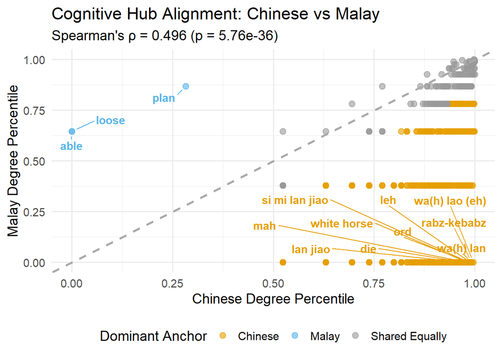

```r
print(plot_chi_mal)
```

```r
plot_chi_ind <- plot_spearman_shift(percentile_shift_chi_ind, "Chinese", "Indian")
```

#### Chinese vs Indian

**Spearman’s rho (ρ):** 0.518

**p-value:** 1.39e-32

**STATISTICAL SIGNIFICANCE:** YES (p < 0.05)

**CONCLUSION:** Moderately Similar. They share a foundation, but have distinct cultural variations.

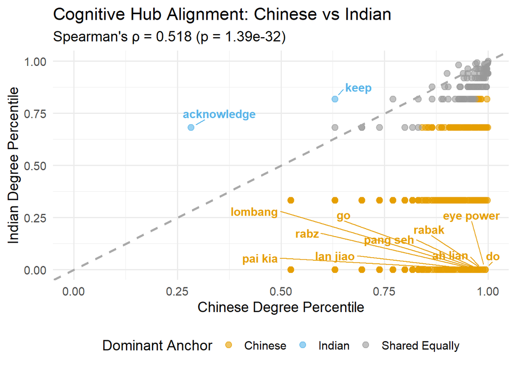

```r
print(plot_chi_ind)
```

```r
plot_mal_ind <- plot_spearman_shift(percentile_shift_mal_ind, "Malay", "Indian")
```

#### Malay vs Indian

**Spearman’s rho (ρ):** -0.089

**p-value:** 0.221

**STATISTICAL SIGNIFICANCE:** NO (p > 0.05)

**CONCLUSION:** Completely Divergent. There is no statistically significant relationship between how these two cultures rank their Singlish hubs.

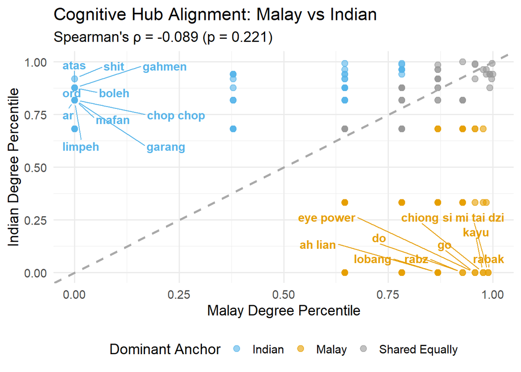

```r
print(plot_mal_ind)
```